# Your Digest for Saturday, Sep 02, 2023 11:59 PM

Indications for therapeutic used:

- postmenopausal osteoporosis
- Paget's disease of bone
- Hypercalcemia

# Regulation of bone formation and resorption - bone metabolism

#TODO osteoporosis

[[Hormone Physiology#Factors influencing bone turnover]]

> [!INFO] Osteoporotic fractures are **extremely** common.  
> In 2 women and 1 in 5 men over 50 years will have one at some point.

> [!INFO] Relationship between serum calcium and osteoporosis  
> Many factors increase bone resorption. See bone metabolism note.  
> With increasing age, there is decreasing ability of the kidneys to activate Vitamin D.  
> This tends to reduce serum calcium leading compensatory hyperparathyroidism.  
> The hyperparathyroidism causes bone resorption.  
> Despite normal calcium levels in osteoporotic patients, because of the mechanism above, dietary calcium supplementation can offset the body's need to resorb bone.

> > You don't need to read this part ->  
> > Intestinal calcium absorption and the ability to adapt to low calcium diets are impaired in many postmenopausal women and elderly persons owing to a suspected functional or absolute decrease in the ability of the kidney to produce 1,25(OH)2D3. The bones then become more and more a source of calcium to maintain critical extracellular fluid calcium levels. Available evidence suggests that the impairments of intestinal calcium absorption observed during the menopause and aging can be overcome only by inordinately large calcium intakes (1500 to 2500 mg/day). Since this amount is difficult to derive from the diet, can cause constipation, and may not prevent trabecular bone loss, it should not be used as a substitute for sex hormone replacement. Women taking estrogen replacement should be provided the RDA for calcium of 800 mg/day at a minimum. Those who cannot or will not take estrogen should be asked to ingest at least 1000 to 1500 mg/day of calcium to delay cortical bone loss and prevent secondary hyperparathyroidism. [Source](https://pubmed.ncbi.nlm.nih.gov/2200470/)

> [!TIP] B12 -> 12 months in a year -> has 2 *years* of reserves

The *apparatus* is made up of ^c5fd5c

- Specialized distal convoluted tubule cells - **macula densa**  
  This unit is important for tubuloglomerular feedback:  
  Macula densa senses DCT sodium levels and sends signals to Juxtraglomerular granular cells to alter afferent arteriolar tone

# Factors regulating renal blood flow

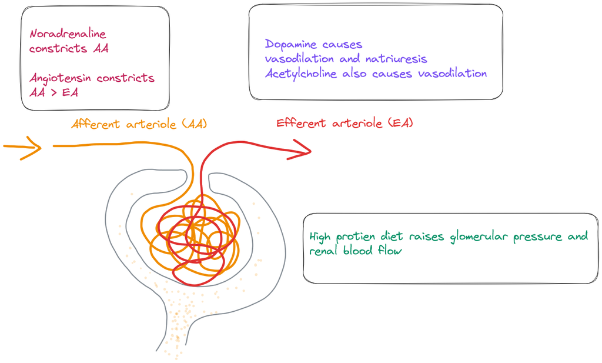

# Renal innervation

## Effects of Noradrenaline on kidneys

- Increased renin release (by acting on renal beta 1 receptors)
- Increased sodium reabsorption (direct action on tubules)
- *Sympathetic stimulation of the kidneys* by noradrenaline mediated nerves **reduces renal blood flow**. This is important in the effector response of the barroreceptor reflex.
  - So during hypotension, exercise and rising from supine position renal blood flow is reduced.

## Na+ - Sodium

> [!INFO] Sodium transport out of all parts of the nephron (except the thin parts of the LOH) is **active!**  
> There is basolateral **NA/K ATPAse** in all these cells

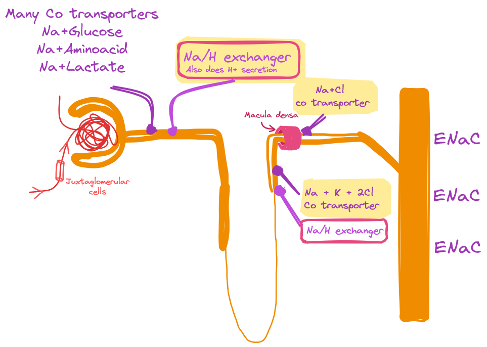

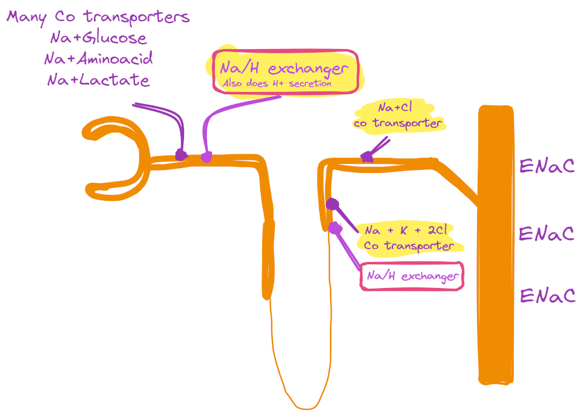

> [!INFO]  
> Major transporter in each region is highlighted yellow.  
> Na/H in PCT - 60% of reabsorption  
> Na + K + 2CL - 30%  
> Na + CL - 7%  
> ENAC - 3%

## Regulation Of Sodium reabsorption

> [!INFO] Sodium is the most important determinant of plasma osmolality

Variations in Na Excretion are produced by

1. changes in GFR (i.e how much sodium is filtered)
2. How much is reabsorbed (mainly by adjusting the 3% of reabsorption in the collecting ducts)

**GFR** is regulated by factors such as tubuloglomerular feed back.

- Tubuloglomerular feeback - low flow in the TAL and DCT triggers increased GFR and vice versa. [[#^c5fd5c]]
  - In tubuloglomerular feedback, the macula densa cells of the DCT sense an increase in the sodium they receive via the tubule and send signals to the afferent arteriolar smooth muscle (to cause vasocontriction of AE) and the juxtaglomerular cells (to reduce renin secretion)
- Glomerulotubular balance is the converse of this:
  - Increased GFR causes increased solute reabsorption in the PCT (mainly Na)
  - so that a constant proportion of the filteres Na is reabsorbed.

> [!INFO] Liddle syndrome  
> Hyperactive ENaC Channels -> Sodium retention + Hypertension

## K+ - potassium

See figure 29.5 in Rang and Dale.

## Carbonic anhydrase inhibitors

They increase HCO3- loss in the urine. This increases loss of Na+ and K+ in the urine.  
Loss of Na+ -> Diuresis. [Source](https://tmedweb.tulane.edu/pharmwiki/doku.php/acetazolamide)

# Compensation of acid base disorders

#2021BSQ-NOV Q12

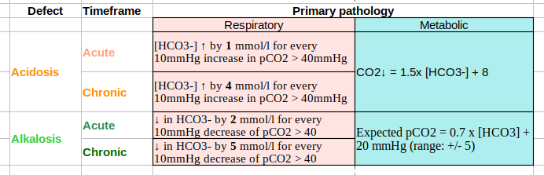

## Metabolic alkalosis

Vomiting and NG suction cause alkalosis because [Source](https://www.ncbi.nlm.nih.gov/pmc/articles/PMC7896805/)

1. With normal swallowing, HCO3 is secreted in the intestine to neutralize the luminal acid, releasing H+ into the circulation.
2. This doesn't happen when gastric juice is lost orally.

> Metabolic alkalosis is usually accompanied by *hypokalemia and hypochloremia*.  
> This reduction in chloride (Cl-) is not accompanied by hyponatremia [Source](https://www.ncbi.nlm.nih.gov/pmc/articles/PMC7896805/)

There are two types of metabolic alkalosis depending on the volume status:  
Low ECF volume + alkalosis => Contraction alkalosis.  
High ECF Volume + alkalosis => Alkaosis with volume expansion.  
Clinical differentiation is with urine chloride.

*Contraction alkalosis -*> **Low urine chloride** (< 20mmol/l)  
*ECF expanstion* -> **Urine chloride** > 20mmol/l.

#TODO - mechanism.

# Antiplatelet medications

Key mediators:  
#TODO review roles

- Thromboxane A2.
- Arachidonic acid pathway
- ADP
- GP IIb/IIa receptors

## Aspirin

- Inhibits COX-1 -> inhibits Thromboxane A2 production
- Platelet cannot make new enzymes (as they're anucleate)
- So platelet activity returns only when new ones are formed in 7-10 days.

## Dipyridamole

- Mechanism: inhibits phosphodiesterase, inhibits thromboxane A2 synthesis.
- Unlike aspirin, it **does not increase bleeding risk**.

## P2Y12 receptor angatonists

- Clopidogrel and prasugrel irreversibly inhibit the binding of adenosine to P2Y12 receptors
- Ticagrelow produces non-competitive reversible inhibition.
- They inhibit adenosine mediated platelet aggregation.
- Clopidogrel is the prodrug. It's activated by the CYP2C19 enzyme system which can be inhibited by **omeprazole!**. Don't co administer the drugs.
- Prasugrel -> rash and angiooedema rarely.
  - Prasugrel is **not used after ischemic stroke / TIA** due to increased bleeding risk.
- Ticagrelor -> dyspnoea.
  - No data for use in post stroke / TIA.

Proof of the benefit of clopidogrel with aspirin:

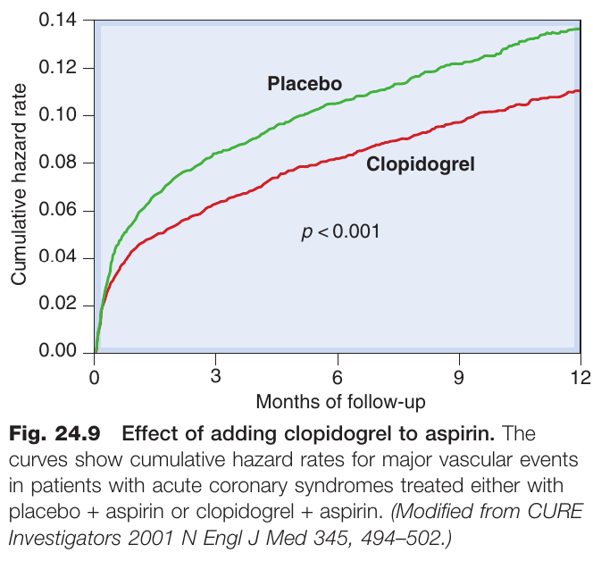

### Glycoprotein IIb/IIIa blockers

- *All platelet activation pathways* **converge** on Gp IIb/IIIa.
- So blockage is theoretically very effective.
- Abciximab is a monoclonal antibody which does this; Only one dose can be given before the body forms effective antibodies to it.
  - Abciximab was also shown to have increased bleeding tendency following stroke so it's not used for this purpose.
- Tirofiban and epitifibadite are also IIb/IIIa blockers which are given IV to reduce early events in ACS.

Parafollicular C cells : Medullary CA. (C cells are neuroendocrine cells and they produce [[Hormone Physiology#Calcitonin|Calcitonin]]).

> [!TIP] Mnemonic for MEN syndromes  
> පා පා පි  
> පා මේ ෆි  
> මා මේ ෆි

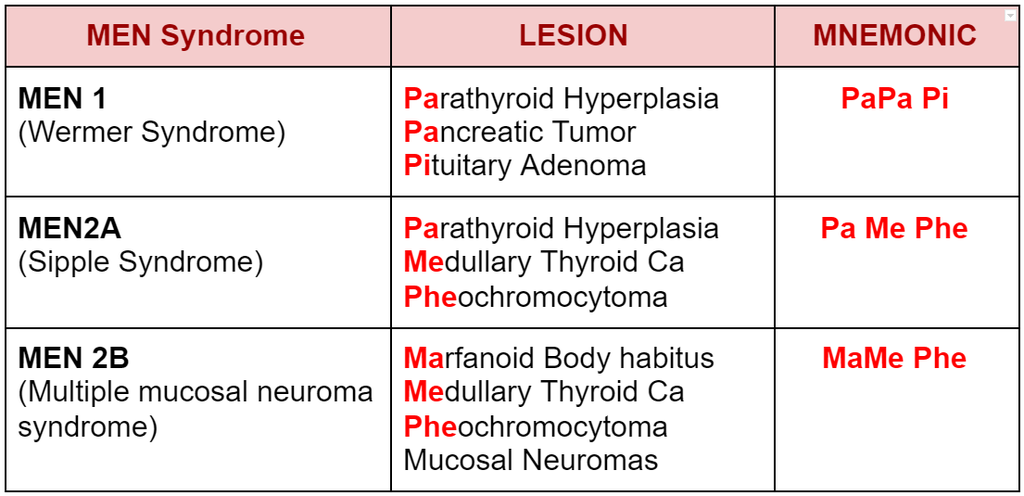